# Classifying images with convolutional neural networks

## Introduction

The CIFAR-10 dataset contains 60,000 RGB images 32 pixels square. There are in 6000 examples of each of the ten objects and animals, with no overlap. The AlexNet architecture was built in TensorFlow as a baseline model, and then was modified using ResNet style residual connections and a dropout layer. To reduce overfitting a series of image transformations were used to change the size, color, and orientation of the training set.

[figure not shown]

## Results

[figure not shown]

- Tuning the type, amount, and rate of data augmentation to provide enough new information without degrading the images beyond recognition was a challenging task, but paid off in better model performance. The use of iterative training sprints kept the model from getting stuck in unproductive paths without leaking too much information from the validation set. The use of dilation also kept the model from over fitting the data, but made it so hard to learn that the model never exceeded the baseline model performance.

## Data

- the CIFAR-10 dataset is available withing the Keras module

## Full code

In this notebook we train three neural networks to identify images from the CIFAR-10 dataset. We explore how changes in architecture like residual connections and dropout layers can improve performance and lighten the number of model parameters. We also explore the use of dilation and data augmentation to generalize the model, making use of an iterative training environment to steer the model towards peak performance on validation and test data.

### Load libraries

```python
#  data handling
import numpy as np
import pandas as pd
import datetime, os
import itertools
import io
from time import time

# image manipulation
from scipy import ndimage
from skimage.io import imread
from skimage import transform
from PIL import Image, ImageOps, ImageFilter
import colorsys

# sklearn
from sklearn.model_selection import train_test_split
from sklearn.preprocessing import MinMaxScaler
from sklearn.linear_model import LogisticRegression
from sklearn.metrics import accuracy_score, confusion_matrix
from sklearn.metrics import precision_score, recall_score

# tensorflow
import tensorflow as tf
from tensorflow import keras
from tensorflow.keras.layers import Dense, Dropout, Flatten, Conv2D, Conv3D, MaxPool2D
from tensorflow.keras import Sequential, Model, layers
from tensorflow.keras.models import save_model, load_model
from tensorflow.keras.optimizers import SGD

# warnings
import warnings
warnings.simplefilter('ignore', category=DeprecationWarning)
warnings.filterwarnings("ignore")

# plotting
from IPython.display import display
import matplotlib.pyplot as plt
import seaborn as sns
import matplotlib
matplotlib.rcParams['figure.figsize'] = [15, 5]
```

##### Helper functions

```python
# Function to plot confusion matrix from class
def plot_confusion_matrix(cm, class_names):
    """
    Returns a matplotlib figure containing the plotted confusion matrix.

    Args:
       cm (array, shape = [n, n]): a confusion matrix of integer classes
       class_names (array, shape = [n]): String names of the integer classes
    """

    figure = plt.figure(figsize=(8, 8))
    plt.imshow(cm, interpolation='nearest', cmap=plt.cm.Blues)
    plt.title("Confusion matrix")
    plt.colorbar()
    tick_marks = np.arange(len(class_names))
    plt.xticks(tick_marks, class_names, rotation=45)
    plt.yticks(tick_marks, class_names)

    # Normalize the confusion matrix.
    cm = np.around(cm.astype('float') / cm.sum(axis=1)[:, np.newaxis], decimals=2)

    # Use white text if squares are dark; otherwise black.
    threshold = cm.max() / 2.

    for i, j in itertools.product(range(cm.shape[0]), range(cm.shape[1])):
        color = "white" if cm[i, j] > threshold else "black"
        plt.text(j, i, cm[i, j], horizontalalignment="center", color=color)

    plt.tight_layout()
    plt.ylabel('True label')
    plt.xlabel('Predicted label')
    return figure

# function to print model accuracies from class
def model_accuracy(model, x_train, train_labels, x_valid, validation_labels, x_test, test_labels):
    train_prob = model.predict(x_train)
    train_pred = np.argmax(train_prob, axis=1)
    train_acc = accuracy_score(train_pred, train_labels.squeeze())
    print('Train Accuracy: {:.4f}'.format(train_acc))

    validation_prob = model.predict(x_valid)
    validation_pred = np.argmax(validation_prob, axis=1)
    validation_acc = accuracy_score(validation_pred, validation_labels.squeeze())
    print('Validation Accuracy: {:.4f}'.format(validation_acc))

    test_prob = model.predict(x_test)
    test_pred = np.argmax(test_prob, axis=1)
    test_acc = accuracy_score(test_pred, test_labels.squeeze())
    print('Test Accuracy: {:.4f}'.format(test_acc))

    # Confusion matrix for test set
    conf_mat_data = confusion_matrix(test_pred, test_labels)
    conf_df = pd.DataFrame(conf_mat_data, columns=class_names, index=class_names)
    display(conf_df)

    return conf_df

def make_grey_20_20(img):
    '''Convert 32x32x3 rgb image to 20x20 greyscale'''
    # convert image to PIL format
    pil_img = Image.fromarray(img)

    # resize using PIL anti-aliasing
    pil_img = pil_img.resize((20, 20), Image.ANTIALIAS)

    # convert back to numpy
    img2 = np.array(pil_img.getdata()).reshape(20, 20, 3)
    img2 = np.where(img2 < 0, 0, img2)
    img2 = np.where(img2 > 255, 255, img2)

    # convert to greyscale from
    # stackoverflow.com/questions/41971663/
    img3 = np.dot(img2[...,:3], [0.299, 0.587, 0.114])

    return img3

def its_a_bird_its_a_plane(X, y):
    '''Select images of birds and planes, reduce to 20x20 greyscale and flatten.'''
    # count planes (0) and birds (2) in target labels
    size_plane = np.sum(y == 0)
    size_bird = np.sum(y == 2)

    # initialize matrices of just bird and plane with zeroes
    X_plane = np.zeros((size_plane, 20, 20))
    X_bird = np.zeros((size_bird, 20, 20))

    # initialize target with plane = 0, bird = 1
    y_plane = np.zeros(size_plane, dtype = 'int')
    y_bird = np.ones(size_bird, dtype = 'int')

    # initialize counters
    count_bird = 0
    count_plane = 0

    # loop over images
    for i in range(len(y)):
        # if a plane (0), convert 32x32x3 image to 20x20 greyscale and add to X_plane
        if y[i] == 0:
            X_plane[count_plane] = make_grey_20_20(X[i])
            count_plane += 1

        # if a bird (2), convert 32x32x3 image to 20x20 greyscale and add to X_bird
        elif y[i] == 2:
            X_bird[count_bird] = make_grey_20_20(X[i])
            count_bird += 1

    # merge the bird and plane images and target labels
    X_bird_plane = np.concatenate((X_bird, X_plane), axis=0)
    y_bird_plane = np.concatenate((y_bird, y_plane), axis=0)

    # flatten 20x20 images to 400 feature array
    X_bird_plane_flat = X_bird_plane.reshape(X_bird_plane.shape[0], 400)

    return (X_bird_plane_flat, y_bird_plane)
```

##### Load CIFAR10 images

```python
# load training and test images
(train_images, train_labels), (test_images, test_labels) = keras.datasets.cifar10.load_data()

# Setup class names
class_names= ['airplane', 'automobile', 'bird', 'cat', 'deer', 'dog', 'frog', 'horse', 'ship', 'truck']

# note the shape of the data
print(train_images.shape)

# Separate validation sets from train sets
validation_images, validation_labels = train_images[:5000], train_labels[:5000]
train_images, train_labels = train_images[5000:], train_labels[5000:]
```

```
(50000, 32, 32, 3)
```

##### Get accuracy baseline with logistic regression

```python
# convert 10x32x32x3 problem to a 2x400 one: pick two targets (bird and plane)
# extract all images matching these targets, resize to 20x20, convert to greyscale
# and flatten to a 400 feature numpy array
start = time()
X_bp_train, y_bp_train = its_a_bird_its_a_plane(train_images, train_labels)
X_bp_valid, y_bp_valid = its_a_bird_its_a_plane(validation_images, validation_labels)

# train a logistic regression model on birds vs planes
solve_start = time()
logit = LogisticRegression(max_iter = 5000, solver = 'sag', n_jobs = -2)
logit.fit(X_bp_train, y_bp_train)

# predict on training and validation data
y_hat_train = logit.predict(X_bp_train)
y_hat_valid = logit.predict(X_bp_valid)

# get accuracy scores
acc_train = accuracy_score(y_bp_train, y_hat_train)
acc_test = accuracy_score(y_bp_valid, y_hat_valid)

print('Table 1')
print(f'Conversion took {solve_start - start:.2f} seconds. Solving took {time() - solve_start:.2f} seconds.')
print("Training data accuracy is {:2.2f}%".format(acc_train * 100))
print("Validation data accuracy is {:2.2f}%".format(acc_test * 100))
```

```
Table 1
Conversion took 4.01 seconds. Solving took 27.10 seconds.
Training data accuracy is 63.85%
Validation data accuracy is 59.77%
```

##### Standardize all images

```python
x_train = train_images.astype("float32") / 255.0
x_valid = validation_images.astype("float32") / 255.0
x_test = test_images.astype("float32") / 255.0

y_train = keras.utils.to_categorical(train_labels, 10)
y_valid = keras.utils.to_categorical(validation_labels, 10)
y_test = keras.utils.to_categorical(test_labels, 10)
```

##### Baseline sequential neural network: Alexnet

```python
def alexnet_model():
    model = Sequential(name="alexnet_model")

    # Layer 1: 3x3 convolution w/ stride 1, & 48 features.
    model.add(Conv2D(48,
                  kernel_size=(3,3),
                  strides=(1,1),
                  activation='relu',
                  padding='same',
                  input_shape=(32, 32, 3)))
    # Followed by Max Pooling
    model.add(MaxPool2D(pool_size=(2,2), strides=(2,2))) # 16x16

    #Layer 2: 3x3 convolution w/ stride 1, & 96 features.
    model.add(Conv2D(96,
                  kernel_size=(3,3),
                  activation='relu',
                  padding='same'))
    # Followed by Max Pooling
    model.add(MaxPool2D(pool_size=(2,2),strides=(2,2))) # 8x8


    #Layer 3: 3x3 convolution w/ stride 1, & 192 features.
    model.add(Conv2D(192,
                  kernel_size=(3,3),
                  activation='relu',
                  padding='same') )
    # Followed by Max Pooling
    model.add(MaxPool2D(pool_size=(2,2),strides=(2,2))) # 4x4

    #Layer 4: 3x3 convolution w/ stride 1, & 192 features.
    model.add(Conv2D(192,
                  kernel_size=(3,3),
                  activation='relu',
                  padding='same'))
    # Followed by Max Pooling
    model.add(MaxPool2D(pool_size=(2,2),strides=(2,2))) # 2x2

    #Layer 5: 3x3 convolution w/ stride 1, & 256 features.
    model.add(Conv2D(256,
                  kernel_size=(3,3),
                  activation='relu',
                  padding='same'))
    # Followed by Max Pooling
    model.add(MaxPool2D(pool_size=(2,2),strides=(2,2))) # 1x1

    # Flatten
    model.add(Flatten()) # flat

    #Layer 6: Dense layer to 512 neurons.
    model.add(Dense(512, activation='tanh'))

    #Layer 7 : Dense layer to 256 neurons.
    model.add(Dense(256, activation='tanh'))

    #Prediction: Dense layer to 10 neurons.
    model.add(Dense(10, activation='softmax'))

    return(model)

print('Figure 1:')
alexnet_model().summary()
```

```
Figure 1:
Model: "alexnet_model"
_________________________________________________________________
Layer (type)                 Output Shape              Param #
=================================================================
conv2d (Conv2D)              (None, 32, 32, 48)        1344
_________________________________________________________________
max_pooling2d (MaxPooling2D) (None, 16, 16, 48)        0
_________________________________________________________________
conv2d_1 (Conv2D)            (None, 16, 16, 96)        41568
_________________________________________________________________
max_pooling2d_1 (MaxPooling2 (None, 8, 8, 96)          0
_________________________________________________________________
conv2d_2 (Conv2D)            (None, 8, 8, 192)         166080
_________________________________________________________________
max_pooling2d_2 (MaxPooling2 (None, 4, 4, 192)         0
_________________________________________________________________
conv2d_3 (Conv2D)            (None, 4, 4, 192)         331968
_________________________________________________________________
max_pooling2d_3 (MaxPooling2 (None, 2, 2, 192)         0
_________________________________________________________________
conv2d_4 (Conv2D)            (None, 2, 2, 256)         442624
_________________________________________________________________
max_pooling2d_4 (MaxPooling2 (None, 1, 1, 256)         0
_________________________________________________________________
flatten (Flatten)            (None, 256)               0
_________________________________________________________________
dense (Dense)                (None, 512)               131584
_________________________________________________________________
dense_1 (Dense)              (None, 256)               131328
_________________________________________________________________
dense_2 (Dense)              (None, 10)                2570
=================================================================
Total params: 1,249,066
Trainable params: 1,249,066
Non-trainable params: 0
_________________________________________________________________
```

- Figure 1: We decided to merge the Alexnet architecture from class with ResNet style residual connections and a dropout layer. ##### Improved convolutional neural network

```python
def alex_resnet_model():
    # input, block 1
    inputs = keras.Input(shape=(32, 32, 3), name="img")
    x = layers.Conv2D(48, kernel_size=(3,3), strides=(1,1), padding="same", activation="relu")(inputs)
    block_1_pool2 = layers.MaxPooling2D(pool_size=(2,2), strides=(2,2))(x) # 16x16

    # block 2
    x = layers.Conv2D(96, kernel_size=(3,3), strides=(1,1), padding="same", activation="relu")(block_1_pool2)
    block_2_merge = layers.Concatenate(axis = 3)([x, block_1_pool2])
    block_2_pool2 = layers.MaxPooling2D(pool_size=(2,2), strides=(2,2))(block_2_merge) # 8x8

    # block 3
    x = layers.Conv2D(144, kernel_size=(3,3), activation="relu", padding="same")(block_2_pool2)
    block_3_merge = layers.Concatenate(axis = 3)([x, block_2_pool2])
    block_3_pool2 = layers.MaxPooling2D(pool_size=(2,2), strides=(2,2))(block_3_merge) # 4x4

    # block 4
    x = layers.Conv2D(240, kernel_size=(3,3), padding="same", activation="relu")(block_3_pool2)
    block_4_merge = layers.Concatenate(axis = 3)([x, block_3_pool2])

    # flatten and extract features
    block_4_global= layers.GlobalMaxPool2D()(block_4_merge) # flat
    x = layers.Dense(256, activation='tanh')(block_4_global)
    x = layers.Dropout(0.1)(x)
    x = layers.Dense(64, activation='tanh')(x)
    outputs = layers.Dense(10, activation='softmax')(x)

    alex_resnet = keras.Model(inputs, outputs, name="alex_resnet")
    return alex_resnet

print('Figure 2:')
alex_resnet_model().summary()
```

```
Figure 2:
Model: "alex_resnet"
__________________________________________________________________________________________________
Layer (type)                    Output Shape         Param #     Connected to
==================================================================================================
img (InputLayer)                [(None, 32, 32, 3)]  0
__________________________________________________________________________________________________
conv2d_5 (Conv2D)               (None, 32, 32, 48)   1344        img[0][0]
__________________________________________________________________________________________________
max_pooling2d_5 (MaxPooling2D)  (None, 16, 16, 48)   0           conv2d_5[0][0]
__________________________________________________________________________________________________
conv2d_6 (Conv2D)               (None, 16, 16, 96)   41568       max_pooling2d_5[0][0]
__________________________________________________________________________________________________
concatenate (Concatenate)       (None, 16, 16, 144)  0           conv2d_6[0][0]
                                                                 max_pooling2d_5[0][0]
__________________________________________________________________________________________________
max_pooling2d_6 (MaxPooling2D)  (None, 8, 8, 144)    0           concatenate[0][0]
__________________________________________________________________________________________________
conv2d_7 (Conv2D)               (None, 8, 8, 144)    186768      max_pooling2d_6[0][0]
__________________________________________________________________________________________________
concatenate_1 (Concatenate)     (None, 8, 8, 288)    0           conv2d_7[0][0]
                                                                 max_pooling2d_6[0][0]
__________________________________________________________________________________________________
max_pooling2d_7 (MaxPooling2D)  (None, 4, 4, 288)    0           concatenate_1[0][0]
__________________________________________________________________________________________________
conv2d_8 (Conv2D)               (None, 4, 4, 240)    622320      max_pooling2d_7[0][0]
__________________________________________________________________________________________________
concatenate_2 (Concatenate)     (None, 4, 4, 528)    0           conv2d_8[0][0]
                                                                 max_pooling2d_7[0][0]
__________________________________________________________________________________________________
global_max_pooling2d (GlobalMax (None, 528)          0           concatenate_2[0][0]
__________________________________________________________________________________________________
dense_3 (Dense)                 (None, 256)          135424      global_max_pooling2d[0][0]
__________________________________________________________________________________________________
dropout (Dropout)               (None, 256)          0           dense_3[0][0]
__________________________________________________________________________________________________
dense_4 (Dense)                 (None, 64)           16448       dropout[0][0]
__________________________________________________________________________________________________
dense_5 (Dense)                 (None, 10)           650         dense_4[0][0]
==================================================================================================
Total params: 1,004,522
Trainable params: 1,004,522
Non-trainable params: 0
__________________________________________________________________________________________________
```

- Figure 2: The model we built is smaller, wider and shorter, but has residual connections and a dropout layer to improve training rates and regularization. ##### Build a neural network with dilation

```python
def alex_resnet_dilation():
    # input, block 1 and 2 combined
    inputs = keras.Input(shape=(32, 32, 3), name="img")
    d1 = layers.Conv2D(48, kernel_size=(3,3), strides=(1,1), dilation_rate=2, activation="relu")(inputs) #28x28
    d2 = layers.Conv2D(96, kernel_size=(3,3), strides=(1,1), padding="same", activation="relu")(d1)
    d3 = layers.Conv2D(96, kernel_size=(3,3), strides=(1,1), dilation_rate=2, activation="relu")(d2) #24x24
    d4 = layers.Conv2D(96, kernel_size=(3,3), strides=(1,1), padding="same", activation="relu")(d3)
    d5 = layers.MaxPooling2D(pool_size=(3,3), strides=(3,3))(d4) #8x8

    # block 3
    x = layers.Conv2D(144, kernel_size=(3,3), activation="relu", padding="same")(d5)
    block_3_merge = layers.Concatenate(axis = 3)([x, d5])
    block_3_pool2 = layers.MaxPooling2D(pool_size=(2,2), strides=(2,2))(block_3_merge) # 4x4

    # block 4
    x = layers.Conv2D(240, kernel_size=(3,3), padding="same", activation="relu")(block_3_pool2)
    block_4_merge = layers.Concatenate(axis = 3)([x, block_3_pool2])

    # flatten and extract features
    block_4_global= layers.GlobalMaxPool2D()(block_4_merge) # flat
    x = layers.Dense(256, activation='tanh')(block_4_global)
    x = layers.Dropout(0.1)(x)
    x = layers.Dense(64, activation='tanh')(x)
    outputs = layers.Dense(10, activation='softmax')(x)

    alex_resnet_dilation = keras.Model(inputs, outputs, name="alex_resnet_dilation")

    return alex_resnet_dilation

print('Figure 3:')
alex_resnet_dilation().summary()
```

```
Figure 3:
Model: "alex_resnet_dilation"
__________________________________________________________________________________________________
Layer (type)                    Output Shape         Param #     Connected to
==================================================================================================
img (InputLayer)                [(None, 32, 32, 3)]  0
__________________________________________________________________________________________________
conv2d_9 (Conv2D)               (None, 28, 28, 48)   1344        img[0][0]
__________________________________________________________________________________________________
conv2d_10 (Conv2D)              (None, 28, 28, 96)   41568       conv2d_9[0][0]
__________________________________________________________________________________________________
conv2d_11 (Conv2D)              (None, 24, 24, 96)   83040       conv2d_10[0][0]
__________________________________________________________________________________________________
conv2d_12 (Conv2D)              (None, 24, 24, 96)   83040       conv2d_11[0][0]
__________________________________________________________________________________________________
max_pooling2d_8 (MaxPooling2D)  (None, 8, 8, 96)     0           conv2d_12[0][0]
__________________________________________________________________________________________________
conv2d_13 (Conv2D)              (None, 8, 8, 144)    124560      max_pooling2d_8[0][0]
__________________________________________________________________________________________________
concatenate_3 (Concatenate)     (None, 8, 8, 240)    0           conv2d_13[0][0]
                                                                 max_pooling2d_8[0][0]
__________________________________________________________________________________________________
max_pooling2d_9 (MaxPooling2D)  (None, 4, 4, 240)    0           concatenate_3[0][0]
__________________________________________________________________________________________________
conv2d_14 (Conv2D)              (None, 4, 4, 240)    518640      max_pooling2d_9[0][0]
__________________________________________________________________________________________________
concatenate_4 (Concatenate)     (None, 4, 4, 480)    0           conv2d_14[0][0]
                                                                 max_pooling2d_9[0][0]
__________________________________________________________________________________________________
global_max_pooling2d_1 (GlobalM (None, 480)          0           concatenate_4[0][0]
__________________________________________________________________________________________________
dense_6 (Dense)                 (None, 256)          123136      global_max_pooling2d_1[0][0]
__________________________________________________________________________________________________
dropout_1 (Dropout)             (None, 256)          0           dense_6[0][0]
__________________________________________________________________________________________________
dense_7 (Dense)                 (None, 64)           16448       dropout_1[0][0]
__________________________________________________________________________________________________
dense_8 (Dense)                 (None, 10)           650         dense_7[0][0]
==================================================================================================
Total params: 992,426
Trainable params: 992,426
Non-trainable params: 0
__________________________________________________________________________________________________
```

- Figure 3: Convolutional layers with dilation were attached to the data input, then scaled down to 8 by 8 dimensions using maxpooling with stride 3 to merge with the original architecture. ### Data augmentation ##### Random rotation

```
Figure 4: Image rotations with increasing range in deeper rounds
```

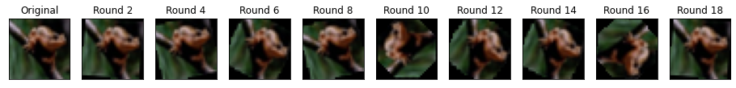

```python
# Random Rotation function, modified from class
def rand_rotation_im(img, count):
    rand_angle = np.random.choice(list(range(1, 5 * (count + 1))) + list(range(360 - 5 * (count + 1), 359)))
    img = ndimage.rotate(img, rand_angle, cval=img.min(), reshape=False)
    img = ndimage.rotate(img, rand_angle, cval=img.min(), reshape=False)
    img = np.where(img < 0, 0, img)
    img = np.where(img > 1, 1, img)
    return img

def show_transform(func):
    fig, axes = plt.subplots(1, 10, figsize = (16,20));
    axes[0].imshow(x_train[0]);
    axes[0].get_xaxis().set_visible(False)
    axes[0].get_yaxis().set_visible(False)
    axes[0].set(title = 'Original')
    for i in range(1,10):
        axes[i].imshow(func(x_train[0], i*2));
        axes[i].set_title(f'Round {i*2}')
        axes[i].get_xaxis().set_visible(False)
        axes[i].get_yaxis().set_visible(False)
    pass

print('Figure 4: Image rotations with increasing range in deeper rounds' )
show_transform(rand_rotation_im)
```

- Figure 4: The goal of the image rotations is to start with small changes and slowly introduce the concept of sideways and upside down images.

##### Exaggerate image edges

```
Figure 5: Enhanced image edges
```

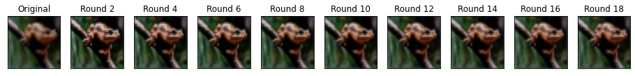

```python
# Emphasize image edges
def image_edges(img, count):
    # convert numpy to PIL
    img2 = img * 255
    img2 = img2.astype('uint8')
    pil_img = Image.fromarray(img2)

    # edge enhance, return to numpy
    pil_img = pil_img.filter(ImageFilter.EDGE_ENHANCE_MORE)
    img3 = np.array(pil_img.getdata()).reshape(pil_img.size[1], pil_img.size[0], 3)
    img3 = img3.astype(float) / 255.0

    # merge the enhanced and original with a bias
    # towards the original that expands over rounds
    bias = count // 4
    merged = ((2 + bias) * img + img3) / (3 + bias)

    # clip any values outside range
    merged = np.where(merged < 0.0, 0.0, merged)
    merged = np.where(merged > 1., 1., merged)

    return merged

print('Figure 5: Enhanced image edges')
show_transform(image_edges)
```

- Figure 5: The goal of image edge emphasis is to exaggerate key features in the image that might distinguish the object from the background. With this filter the amount of exaggeration decays over rounds because multiple rounds will start to degrade the image.

##### Left right flip the image

```
Figure 6: Image mirroring
```

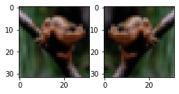

```python
# flip a single image (3D)
def left_right_flip(img, count = 1):
    return np.fliplr(img)

# flip every image in 4D stack
def left_right_flip_all(x_train, y_train):
    x_train_flip = x_train.copy()
    for i in range(x_train.shape[0]):
        x_train_flip[i] = np.fliplr(x_train[i])

    x_train = np.concatenate((x_train, x_train_flip), axis=0)
    y_train = np.concatenate((y_train, y_train), axis=0)

    return (x_train, y_train)

print('Figure 6: Image mirroring')
fig, (ax1, ax2) = plt.subplots(1,2, figsize = (4,10));
ax1.imshow(x_train[0]);
ax2.imshow(left_right_flip(x_train[0], 1));
```

##### Resizing the image

```
Figure 7: Randomly resize the images
```

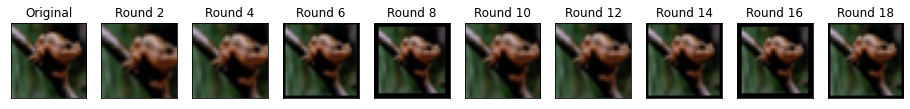

```python
# image resize
# got some code from https://jdhao.github.io/2017/11/06/resize-image-to-square-with-padding/
def image_resize(img, count):
    # convert image to PIL format
    img = img * 255
    img = img.astype('uint8')
    pil_img = Image.fromarray(img)

    # choose a new size to resize to, less dramatic changes over rounds
    if count < 5:
        shrink = np.random.choice([38, 36, 28, 26, 24])
    elif 10 > count >= 5:
        shrink = np.random.choice([36, 34, 30, 28, 26])
    else:
        shrink = np.random.choice([34, 30, 28])

    # determine padding for smaller images, new size
    pad = max([(32 - shrink)//2, 0])
    new_size = (shrink, shrink)

    # resize using PIL anti-aliasing
    pil_img = pil_img.resize(new_size, Image.ANTIALIAS)

    # paste into center of new image
    new_im = Image.new("RGB", (32, 32))
    new_im.paste(pil_img, (pad, pad))

    # convert back to numpy
    img2 = np.array(new_im.getdata()).reshape(new_im.size[1], new_im.size[0], 3)

    img2 = np.where(img2 < 0, 0, img2)
    img2 = np.where(img2 > 255, 255, img2)

    # return image normalize to 0-1
    return  (img2.astype(float)) / (255.0)

print('Figure 7: Randomly resize the images')
show_transform(image_resize)
```

- Figure 7: Resizing the image should help the model generalize feature. The amount of resizing was constricted and biased towards size reduction due to the greater information loss from cropping. Translation was considered but rejected to reduce information loss and focus the model on the center of the image. This strategy is specific to CIFAR and should be reconsidered for other image sets.

#### Change the color tone of the image

```
Figure 8: Changing to color cast of the image
```

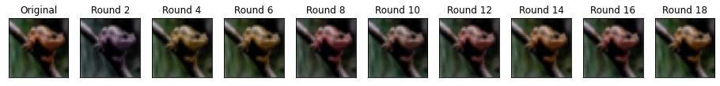

```python
# modified code from
# https://www.semicolonworld.com/question/55219/changing-image-hue-with-python-pil
def shift_hue(arr, hout):
    rgb_to_hsv = np.vectorize(colorsys.rgb_to_hsv)
    hsv_to_rgb = np.vectorize(colorsys.hsv_to_rgb)
    r, g, b, a = np.rollaxis(arr, axis=-1)
    h, s, v = rgb_to_hsv(r, g, b)
    h = hout
    r, g, b = hsv_to_rgb(h, s, v)
    arr = np.dstack((r, g, b, a))
    return arr

def random_hue(img, count):
    """
    Colorize numpy image `original` with random
    `hue` (hue within 0-360); returns another numpy image.
    """
    # convert image to PIL
    img2 = img * 255
    img2 = img2.astype('uint8')
    pil_img = Image.fromarray(img2)

    # convert PIL image to RGBA, then to numpy
    rgba = pil_img.convert('RGBA')
    arr = np.array(np.asarray(rgba).astype('float'))

    # shift hue and convert back to PIL
    hue = np.random.choice(range(0, 360))
    new_im = Image.fromarray(shift_hue(arr, hue/360.).astype('uint8'), 'RGBA')
    new_im = new_im.convert('RGB')

    # convert back to numpy and normalize image  to 0-1
    img3 = np.array(new_im.getdata()).reshape(new_im.size[1], new_im.size[0], 3)
    img3 = (img3.astype(float)) / (255.0)

    # merge the enhanced and original with a bias
    # towards the original that expands over rounds
    bias = count // 4
    merged = ((1 + bias) * img + 1 * img3) / (2 + bias)

    # clip any values outside range
    merged = np.where(merged < 0.0, 0.0, merged)
    merged = np.where(merged > 1., 1., merged)

    return merged

print('Figure 8: Changing to color cast of the image')
show_transform(random_hue)
```

- Figure 8: Changes in color tone were achieved using small shifts in hue, merged back into the original image. The goal was to simulate different lighting situations while still producing realistic color palettes. ##### Augment random rows with random augmentations
- This function with take a fraction of the data and 'mutate' it with one of the above transformations.

```python
# start for loop with how many rounds to iterate over
def train_data_augment(x_train, y_train, fraction = 10, count =1):
    # get values for fraction the data for train and valid
    aug_count_t = len(x_train)//fraction

    # set up temp duplicate images
    x_train_aug = x_train.copy()
    y_train_aug = y_train.copy()

    # randomly select fraction of the images as a list of rows
    rows_t = np.random.choice(range(x_train.shape[0]), aug_count_t, replace = False)

    #loop over training data to augment
    for row in rows_t:
        n = np.random.rand()
        if n < 0.25:
            x_train_aug[row] = random_hue(x_train[row], count)
        elif n < 0.5:
            x_train_aug[row] = image_edges(x_train[row], count)
        elif n < 0.75:
            x_train_aug[row] = image_resize(x_train[row], count)
        else:
            x_train_aug[row] = rand_rotation_im(x_train[row], count)

        # assign correct target label
        y_train_aug[row] = y_train[row]

    return (x_train_aug, y_train_aug)
```

### Model testing

- Due to long training times only one model will be trained at a time. Models are selected by commenting and uncommenting lines 20-22. The boolean augment variable on line 5 determines whether the model is trained on augmented data or not. If augment is selected, one divided by FRACTION percent of the data is mutated each round. The EPOCHS determine how many epochs the model runs before starting a new round, tracked by the count variable. Each round loads the model from the last round with the best validation set accuracy. The batch size is increased every 5 rounds using the sequence in the batch_sizes list. The history of all the training is stored in a dictionary and then exported to a csv file.

```python
# how many epoch of data fitting per round
EPOCHS = 1

# whether to train on augmented data or not
augment = True

# what fraction of the data to mutate with augmentation each round
FRACTION = 20

# every 5 rounds the batch size increases to generalize and fine tune
batch_sizes = [64, 128, 128, 256, 512, 512, 1028, 1028]

# collect the accuracy and loss for each round
history_dict = {}

# how many rounds (count) to train
for count in range(0,1):
    # choose a model to load
    if count == 0:
        current_model = alex_resnet_model() # Alexnet/ResNet hybrid
#         current_model = alex_resnet_dilation_only() # Alexnet/ResNet hybrid with dilation
#         current_model = alexnet_model() # model from class
        print(f'Training a {current_model.name} model ', end = '')
        if augment:
            print('with data augmentation.')
        else:
            print('without data augmentation.')

        # compile model with Adam solver
        current_model.compile(optimizer = 'adam', metrics=['acc'],
              loss=keras.losses.CategoricalCrossentropy(from_logits=True))

    # continue training a model from checkpoint
    else:
        current_model = tf.keras.models.load_model(f'{current_model.name}_{count - 1}.ckpt')

    # scale batch size to round
    batch_size = batch_sizes[min([count//5, len(batch_sizes)])]

    # augment the data if selected
    if augment:
        if count == 0:
            print('Mirroring all data. ', end = '')
            x_train, y_train = left_right_flip_all(x_train, y_train)
            print(f'New training data shape: {x_train.shape}')
        print(f'Augmenting {(1/FRACTION) * 100:.2f}% of the training data.', end = '')
        x_train, y_train = train_data_augment(x_train, y_train, fraction = FRACTION, count = count)
        print('Data augmentation complete')

    # filepath for checkpoints
    checkpoint_path = f'{current_model.name}_{count}.ckpt'

    # create a callback that saves the best model
    model_checkpoint_callback = tf.keras.callbacks.ModelCheckpoint(
            filepath=checkpoint_path, save_weights_only=False,
            monitor='val_acc', mode='max', save_best_only=True)

    # fit the model
    model_logs = current_model.fit(x_train, y_train,
                       epochs = EPOCHS,
                       batch_size = batch_size,
                       validation_data = (x_valid, y_valid),
                       callbacks = [model_checkpoint_callback],
                       verbose = 1)

    # save training information
    history_dict[count] = model_logs.history
    best = np.argmax(history_dict[count]["val_acc"])
    print(f'Round {count}:\tTraining {history_dict[count]["acc"][best]*100:.2f}', end = '\t')
    print(f'Validation {history_dict[count]["val_acc"][best]*100:.2f}\n')

# Save training information to a csv file
hist = []
for round_, score_logs in history_dict.items():
    for score_type, score_values in score_logs.items():
        for epoch, score in enumerate(score_values):
            hist.append({'model' : f'{current_model.name}', 'augmented' : f'{augment}',
                'round' : round_, 'score_type' : score_type, 'epoch' : epoch, 'score' : score})
pd.DataFrame(hist).to_csv(f'{current_model.name}_aug_{augment}.csv', index = False)
```

```
Training a alex_resnet model with data augmentation.
Mirroring all data. New training data shape: (90000, 32, 32, 3)
Augmenting 5.00% of the training data.Data augmentation complete
Instructions for updating:
This property should not be used in TensorFlow 2.0, as updates are applied automatically.
WARNING:tensorflow:From /Users/seankoenig/anaconda3/envs/tf_env/lib/python3.8/site-packages/tensorflow/python/training/tracking/tracking.py:111: Layer.updates (from tensorflow.python.keras.engine.base_layer) is deprecated and will be removed in a future version.
Instructions for updating:
This property should not be used in TensorFlow 2.0, as updates are applied automatically.
INFO:tensorflow:Assets written to: alex_resnet_0.ckpt/assets
Round 0:	Training 45.57	Validation 57.32
```

```
Figure 8:
```

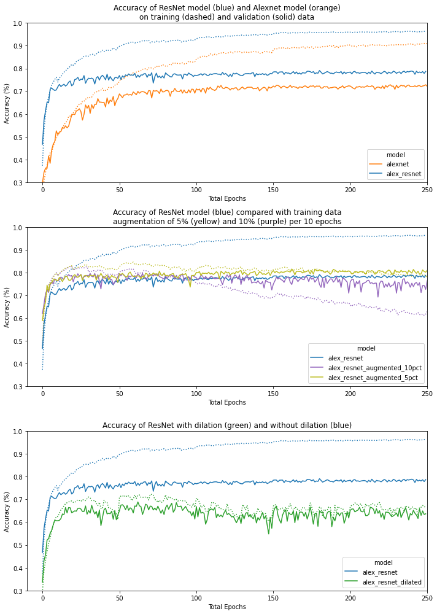

```python
# retrieve results from csv (computations made on a Colab GPU core for speed)
results = pd.read_csv('model_results.csv')

# plot accuracy results vs baseline
mods1 = {'alex_resnet' : 'tab:blue', 'alexnet' : 'tab:orange'}
fig, axes = plt.subplots(3, 1, figsize = (10,14))
axes[0] = sns.lineplot(x = 'total_epochs', y = 'acc', hue = 'model', palette = mods1, linestyle= ':',
                       data = results.loc[results['model'].isin(mods1.keys())], ax  = axes[0]);
axes[0] = sns.lineplot(x = 'total_epochs', y = 'val_acc', hue = 'model', palette = mods1, legend = False,
                  data = results.loc[results['model'].isin(mods1.keys())], ax  = axes[0]);
axes[0].set(title = 'Accuracy of ResNet model (blue) and Alexnet model (orange)\non training (dashed) and validation (solid) data',
       xlabel = 'Total Epochs', xlim = (-10, 250), ylim = (0.3, 1), ylabel = 'Accuracy (%)');

# plot accuracy results vs augmented
mods2 = {'alex_resnet' : 'tab:blue', 'alex_resnet_augmented_10pct' : 'tab:purple', 'alex_resnet_augmented_5pct' : 'tab:olive'} # do 5 and 10%
axes[1] = sns.lineplot(x = 'total_epochs', y = 'acc', hue = 'model', palette = mods2, linestyle= ':',
                       data = results.loc[results['model'].isin(mods2.keys())], ax  = axes[1]);
axes[1] = sns.lineplot(x = 'total_epochs', y = 'val_acc', hue = 'model', palette = mods2, legend = False,
                  data = results.loc[results['model'].isin(mods2.keys())], ax  = axes[1]);
axes[1].set(title = 'Accuracy of ResNet model (blue) compared with training data\naugmentation of 5% (yellow) and 10% (purple) per 10 epochs',
       xlabel = 'Total Epochs', xlim = (-10, 250), ylim = (0.3, 1), ylabel = 'Accuracy (%)');

# plot accuracy results vs dilation
mods3 = {'alex_resnet' : 'tab:blue', 'alex_resnet_dilated' : 'tab:green'}
axes[2] = sns.lineplot(x = 'total_epochs', y = 'acc', hue = 'model', palette = mods3, linestyle= ':',
                       data = results.loc[results['model'].isin(mods3)], ax  = axes[2]);
axes[2] = sns.lineplot(x = 'total_epochs', y = 'val_acc', hue = 'model', palette = mods3, legend = False,
                  data = results.loc[results['model'].isin(mods3)], ax  = axes[2]);
axes[2].set(title = 'Accuracy of ResNet with dilation (green) and without dilation (blue)',
       xlabel = 'Total Epochs', xlim = (-10, 250), ylim = (0.3, 1), ylabel = 'Accuracy (%)');
plt.tight_layout();

print('Figure 8:')
```

### Examine the top performance of each model

```python
# find the best version of each model
best_version = pd.DataFrame()
for model in results['model'].unique():
    best_version = pd.concat([best_version, results.loc[(results['model'] == model)].sort_values(by = 'val_acc', ascending = False).head(1)], axis = 0)

print('Table 2: Best performance for each model')
best_version = best_version[['model', 'acc', 'val_acc', 'total_epochs']].reset_index(drop = True)
best_version.columns = ['Model', 'Training Accuracy', 'Validation Accuracy', 'Total Epochs Trained']
best_version
```

```
Table 2: Best performance for each model
```

|  | Model | Training Accuracy | Validation Accuracy | Total Epochs Trained |
| --- | --- | --- | --- | --- |
| 0 | alexnet | 0.928644 | 0.7340 | 389 |
| 1 | alex_resnet | 0.957489 | 0.7912 | 180 |
| 2 | alex_resnet_augmented_10pct | 0.800978 | 0.7966 | 65 |
| 3 | alex_resnet_augmented_5pct | 0.778244 | 0.8170 | 329 |
| 4 | alex_resnet_dilated | 0.718000 | 0.6890 | 62 |

### Evaluate top models on test data

##### Accuracy and confusion matrix for the Alexnet model from class

```python
# reload un-augmented data
x_train = train_images.astype("float32") / 255.0
x_valid = validation_images.astype("float32") / 255.0
x_test = test_images.astype("float32") / 255.0

# Load top baseline model
print('Table 3: Results from the Alexnet model')
try:
    top_alexnet_model = tf.keras.models.load_model('alexnet.ckpt')
    alexnet_cm = model_accuracy(top_alexnet_model, x_train, train_labels, x_valid, validation_labels, x_test, test_labels)
except:
    print('Train Accuracy: 0.9297\nValidation Accuracy: 0.7340\nTest Accuracy: 0.7215')
```

```
Table 3: Results from the Alexnet model
Train Accuracy: 0.9297
Validation Accuracy: 0.7340
Test Accuracy: 0.7215
```

|  | airplane | automobile | bird | cat | deer | dog | frog | horse | ship | truck |
| --- | --- | --- | --- | --- | --- | --- | --- | --- | --- | --- |
| airplane | 801 | 24 | 86 | 32 | 23 | 14 | 7 | 22 | 82 | 44 |
| automobile | 14 | 829 | 3 | 9 | 5 | 4 | 7 | 1 | 40 | 70 |
| bird | 47 | 6 | 593 | 68 | 56 | 39 | 39 | 32 | 10 | 5 |
| cat | 17 | 5 | 75 | 526 | 58 | 192 | 44 | 49 | 14 | 14 |
| deer | 15 | 2 | 87 | 77 | 691 | 40 | 44 | 56 | 7 | 10 |
| dog | 7 | 8 | 46 | 147 | 42 | 614 | 30 | 47 | 9 | 7 |
| frog | 10 | 9 | 69 | 71 | 48 | 31 | 804 | 16 | 13 | 14 |
| horse | 11 | 3 | 25 | 30 | 57 | 46 | 9 | 760 | 2 | 16 |
| ship | 49 | 25 | 9 | 13 | 15 | 13 | 10 | 3 | 799 | 22 |
| truck | 29 | 89 | 7 | 27 | 5 | 7 | 6 | 14 | 24 | 798 |

- Table 3: The model from class achieved an accuracy of 72.15% on test data, just below the 73.4% it scored on the validation set. This indicates that despite repeated model selection based on training accuracy there was not significant target leakage into the training process. From the confusion matrix we see the model struggled with animals, particularly birds, cats and dogs.

##### Accuracy and confusion matrix for the Resnet model we developed

```
Table 4: Results from the Alex-Resnet model
Train Accuracy: 0.9610
Validation Accuracy: 0.7912
Test Accuracy: 0.7694
```

|  | airplane | automobile | bird | cat | deer | dog | frog | horse | ship | truck |
| --- | --- | --- | --- | --- | --- | --- | --- | --- | --- | --- |
| airplane | 841 | 15 | 54 | 27 | 20 | 12 | 6 | 16 | 67 | 39 |
| automobile | 13 | 878 | 4 | 7 | 1 | 5 | 6 | 1 | 20 | 55 |
| bird | 46 | 5 | 708 | 69 | 72 | 63 | 43 | 41 | 19 | 6 |
| cat | 12 | 4 | 51 | 568 | 64 | 132 | 51 | 28 | 15 | 12 |
| deer | 8 | 1 | 56 | 48 | 718 | 33 | 19 | 58 | 7 | 3 |
| dog | 3 | 7 | 47 | 167 | 37 | 684 | 27 | 58 | 6 | 8 |
| frog | 8 | 5 | 50 | 65 | 41 | 20 | 834 | 5 | 5 | 7 |
| horse | 6 | 4 | 12 | 22 | 42 | 39 | 4 | 776 | 1 | 7 |
| ship | 35 | 17 | 13 | 11 | 5 | 4 | 4 | 0 | 836 | 12 |
| truck | 28 | 64 | 5 | 16 | 0 | 8 | 6 | 17 | 24 | 851 |

```
Figure 9: Heatmap of improvements (red) in the confusion matric using the ResNet architecture
```

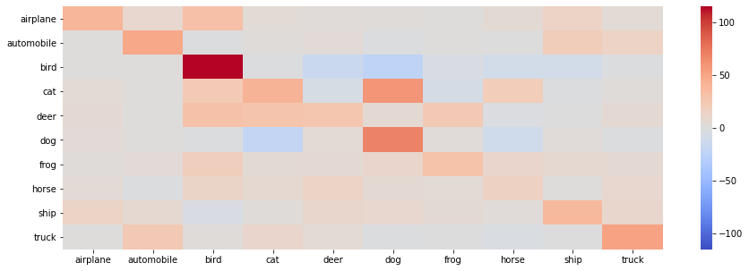

```python
# Load top alex resnet model
print('Table 4: Results from the Alex-Resnet model')
try:
    top_alex_resnet_model = tf.keras.models.load_model('alex_resnet.ckpt')
    alex_resnet_cm = model_accuracy(top_alex_resnet_model, x_train, train_labels, x_valid, validation_labels, x_test, test_labels)
except:
    print('Train Accuracy: 0.9610\nValidation Accuracy: 0.7912\nTest Accuracy: 0.7694')

try:
    difference = alex_resnet_cm.values - alexnet_cm.values
    for i in range(10):
        difference[i][i] = - difference[i][i]
    max_ = max([np.max(difference), - np.min(difference)])
except:
    difference = np.array([[-40,-9,-32,-5,-3,-2,-1,-6,-15,-5],[-1,-49,1,-2,-4,1,-1,0,-20,-15],
    [-1,-1,-115,1,16,24,4,9,9,1],[-5,-1,-24,-42,6,-60,7,-21,1,-2],[-7,-1,-31,-29,-27,-7,-25,2,0,-7],
    [-4,-1,1,20,-5,-70,-3,11,-3,1],[-2,-4,-19,-6,-7,-11,-30,-11,-8,-7],[-5,1,-13,-8,-15,-7,-5,-16,-1,-9],
    [-14,-8,4,-2,-10,-9,-6,-3,-37,-10],[-1,-25,-2,-11,-5,1,0,3,0,-53]])

print('Figure 9: Heatmap of improvements (red) in the confusion matric using the ResNet architecture')
sns.heatmap(pd.DataFrame(difference*-1, index = class_names, columns = class_names),
            center = 0, cmap = 'coolwarm', vmax = max_, vmin =-max_);
```

- Table 4: The model we developed using residual connections achieved an accuracy of 76.94% on test data, significantly above 72.15% of the baseline model, but well below the 79.12% it scored on the validation set. This indicates that there may have been target leakage from the validation set into the training process. From the confusion matrix we see the model struggled with the same animals as the Alexnet model from class.
- Figure 9: Looking at the heatmap comparison, there were improvement (red) in true positives for every category, particularly birds.

##### Accuracy and confusion matrix for the ResNet model with data augmentation

```
Table 5: Results from the Alex-Resnet model with data augmentation
Train Accuracy: 0.8873
Validation Accuracy: 0.8170
Test Accuracy: 0.7991
```

|  | airplane | automobile | bird | cat | deer | dog | frog | horse | ship | truck |
| --- | --- | --- | --- | --- | --- | --- | --- | --- | --- | --- |
| airplane | 821 | 16 | 50 | 29 | 15 | 13 | 6 | 14 | 43 | 22 |
| automobile | 7 | 879 | 3 | 6 | 1 | 2 | 3 | 2 | 8 | 48 |
| bird | 40 | 6 | 755 | 69 | 62 | 42 | 56 | 26 | 14 | 3 |
| cat | 12 | 6 | 37 | 591 | 36 | 109 | 57 | 26 | 14 | 14 |
| deer | 13 | 1 | 54 | 63 | 768 | 32 | 32 | 23 | 3 | 2 |
| dog | 3 | 6 | 43 | 155 | 23 | 740 | 29 | 31 | 2 | 10 |
| frog | 6 | 3 | 22 | 30 | 18 | 11 | 800 | 2 | 3 | 1 |
| horse | 17 | 3 | 27 | 32 | 69 | 39 | 7 | 870 | 6 | 10 |
| ship | 54 | 27 | 7 | 10 | 4 | 5 | 6 | 1 | 895 | 18 |
| truck | 27 | 53 | 2 | 15 | 4 | 7 | 4 | 5 | 12 | 872 |

```
Figure 10: Heatmap of improvements (red) in the confusion matric using data augmentation
```

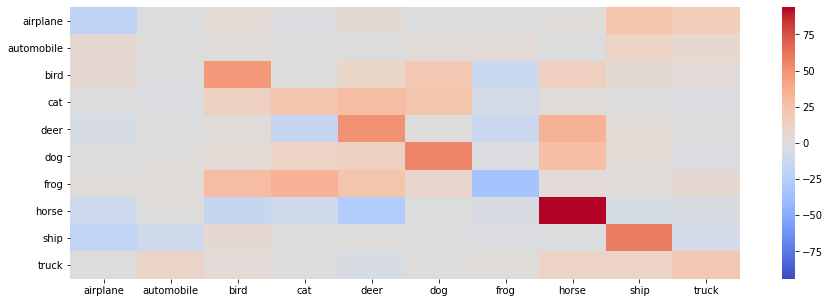

```python
# Load top augmented resnet model
print('Table 5: Results from the Alex-Resnet model with data augmentation')
try:
    top_alex_resnet_augmented = tf.keras.models.load_model('alexnet_aug_5pct.ckpt')
    alex_resnet_cm_aug = model_accuracy(top_alex_resnet_augmented, x_train, train_labels, x_valid, validation_labels, x_test, test_labels)
except:
    print('Train Accuracy: 0.8873\nValidation Accuracy: 0.8170\nTest Accuracy: 0.7991')

try:
    aug_difference = alex_resnet_cm_aug.values - alex_resnet_cm.values
    for i in range(10):
        aug_difference[i][i] = - aug_difference[i][i]

    max_ = max([np.max(aug_difference), - np.min(aug_difference)])
except:
    aug_difference = np.array([[20,1,-4,2,-5,1,0,-2,-24,-17],[-6,-1,-1,-1,0,-3,-3,1,-12,-7],
    [-6,1,-47,0,-10,-21,13,-15,-5,-3],[0,2,-14,-23,-28,-23,6,-2,-1,2],[5,0,-2,15,-50,-1,13,-35,-4,-1],
    [0,-1,-4,-12,-14,-56,2,-27,-4,2],[-2,-2,-28,-35,-23,-9,34,-3,-2,-6],[11,-1,15,10,27,0,3,-94,5,3],
    [19,10,-6,-1,-1,1,2,1,-59,6],[-1,-11,-3,-1,4,-1,-2,-12,-12,-21]])

print('Figure 10: Heatmap of improvements (red) in the confusion matric using data augmentation')
sns.heatmap(pd.DataFrame(aug_difference * -1, index = class_names, columns = class_names),
            center = 0, cmap = 'coolwarm', vmax = max_, vmin =-max_);
```